# Statistical Inference, Course Project - Part1

Ivan Maksimov

08.01.2015

# Introdaction

## Objectives

In this project we should

1. Show the sample mean and compare it to the theoretical mean of the distribution.
2. Show how variable the sample is (via variance) and compare it to the theoretical variance of the distribution.
3. Show that the distribution is approximately normal.

# Data Processing

## Exponential sampling parameters

The exponential distribution can be randomly generated in R with the function `rexp(n, lambda)` where n is the number of observations and $\lambda$ is the rate parameter. Set $\lambda = 0.2$ for all of the simulations. We investigate the distribution of averages of 40 exponentials and need to do a thousand simulations.

```r
lambda <- 0.2 #Set rate to 0.2
sampleSize <- 40 #Set sample size to 40
nSamples <- 1000 #Draw 1000 samples
```

Let’s do a thousand simulated averages of 40 exponentials.

```r
expoDist <- replicate(n = nSamples, expr = rexp(n = sampleSize, lambda))
```

## Calculate theoretical and sample summary statistics

### Means

```r
theoMean <- round((1/lambda), 3) #Theoretical
sampleMean <- round(mean(colMeans(expoDist)), 3) #Sample
```

### Standard Deviations

```r
theoSd <- round((1/lambda * (1/sqrt(sampleSize))), 3) #Theoretical
sampleSd <- round(sd(colMeans(expoDist)), 3) #Sample
```

### Variance

```r
theoVar <- round((theoSd^2), 3)
sampleVar <- round((sampleSd^2), 3)
```

## Summary statistics and inferences

The theoretical and empirical summary statistics of the simulated exponential distribution for this exercise can be verified in Table 1 bellow.

Table 1: Summary statistics

|  | Mean | Standart Diviation | Variance |
| --- | --- | --- | --- |
| Theoretical | 5 | 0.791 | 0.626 |
| Sample | 4.983 | 0.79 | 0.624 |

### Answer to objective 1

The center of the simulated sampling distribution (4.983) is very close to the theoretical center (5) of the distribution.

### Answer to objective 2

The standard deviation of sampling 0.79 is also close to the theoretical standard deviation of 0.791.

### Answer to objective 3

Due to the central limit theorem, the averages of samples follow normal distribution. The figure above also shows the density computed using the histogram and the normal density plotted with theoretical mean and variance values.

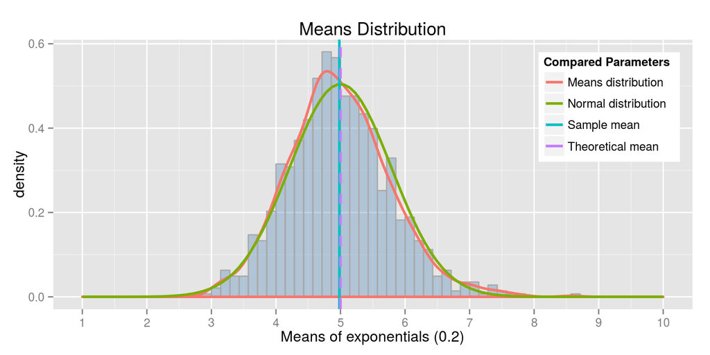

```r
library(ggplot2)
hist.df <- data.frame(Means = colMeans(expoDist))
ggplot(data = hist.df, aes(x = Means)) +
        geom_histogram(aes(y=..density..), fill = "steelblue",
                       binwidth = 1/7, color = "darkgrey", alpha = 1/3) +
        geom_density(aes(color = "Means distribution"), size = 1, show_guide=FALSE)+
        stat_function(fun=dnorm, arg=list(mean=theoMean, sd=theoSd),
                      aes(color = "Normal distribution"), size = 1)+
        geom_vline(aes(xintercept=sampleMean, colour="Sample mean"), size = 1)+
        geom_vline(aes(xintercept=theoMean,colour = "Theoretical mean"), size = 1, linetype="dashed")+
        theme(legend.justification=c(1,0), legend.position=c(1,0.5))+
        labs(title = "Means Distribution", x = "Means of exponentials (0.2)")+
        scale_x_continuous(limits = c(1, 10), breaks=1:10)+
        scale_color_discrete(name ="Compared Parameters")
```